# Exponentiation modulaire

À de nombreuses occasions (th. de Fermat, RSA, ...), nous pouvons souhaiter calculer des nombres de la forme $a^b\pmod{n}$, avec $a\in\mathbb{Z}$, $b\in\mathbb{N}$ et $n\in\mathbb{N}$, $n\neq 0$.

Ce que nous voulons donc c'est réaliser une fonction paramétrée par trois nombres entiers $a$, $b$ et $n$ qui renvoie l'unique entier $r\in[0, n-1]$ tel que $a^b\equiv r \pmod{n}$.

```
def expo_mod(a, b, n):
    '''
    :param a: (int)
    :param b: (int) exposant
    :param n: (int) modulus
    :return: (int) r dans [0, n-1] tel que a^b = r (mod n)
    :CU: n > 0, b >= 0
    :Exemples:

    >>> expo_mod(2, 10, 100)
    24
    >>> expo_mod(14, 3141, 17)
    12
    '''
```

## Première solution

La première idée qui vient pour réaliser cette fonction est d'utiliser les opérateurs d'exponentiation et modulo de Python.

```python
def expo_mod(a, b, n):
    '''
    :param a: (int)
    :param b: (int) exposant
    :param n: (int) modulus
    :return: (int) r dans [0, n-1] tel que a^b = r (mod n)
    :CU: n > 0, b >= 0
    :Exemples:

    >>> expo_mod(2, 10, 100)
    24
    >>> expo_mod(14, 3141, 17)
    12
    '''
    return a**b % n
```

Et ça marche très bien ...

```python
expo_mod(2, 10, 100)
```

```
24
```

```python
expo_mod(14, 3141, 17)
```

```
12
```

... mais avec de grands nombres ?

```python
# Après deux minutes de calculs pas de réponse
# expo_mod(123456789, 987654321, 10**9)
```

## Algorithme d'exponentiation rapide

### Deux pièges à éviter

Lorsqu'on veut calculer $a^b\pmod{n}$ avec de grands nombres entiers il y a deux pièges à éviter :

1. calculer d'abord $a^b$, puis calculer le reste de la division par $n$ (c'est ce qu'on a en tête lorsqu'on écrit en Python `a**b % n` ;
2. calculer $a^b$ selon la définition même d'une élévation à la puissance, i.e. par $b$ multiplications répétées par $a$ : $a^b =a\times a\times \ldots\times a$.

**La première idée** est à éviter pour des raisons d'espace de travail (quantité de papier pour écrire les nombres en jeu, quantité de mémoire pour stocker ces nombres). En effet, si on note $|n|_\beta$ la taille de la représentation d'un nombre entier $n$ (non nul) lorsqu'il est écrit en base $\beta$, on a

$$ |n|_\beta = \lfloor\log_\beta{n}\rfloor + 1.$$

(La notation $\lfloor x\rfloor$ désigne la partie entière inférieure (les anglophones disent «*plancher*» (*floor* en anglais) du nombre réel $x$, i.e. le plus grand entier inférieur ou égal à $x$.

(**Exercice :** démontrez cette affirmation.)

Par conséquent, la taille du nombre $a^b$ est $$|a^b|_\beta = \lfloor b\log_\beta{a}\rfloor + 1,$$ ce qui pour de très grands nombres $a$ et $b$ donne $$|a^b|_\beta \approx b\log_\beta{a}.$$

Autrement dit, la taille de $a^b$ est approxivement égal à $b$ fois la taille de $a$.

Avec des nombres de quelques centaines de chiffres en base 10 (ie quelques milliers en base 2), la taille des nombres ainsi considérés dépasse très largement la quantité de mémoire du plus gros des ordinateurs imaginables (en fait, ces nombres sont plus grands (de plusieurs ordres de grandeurs) que le nombre de particules dans tout l'univers) qui est estimé à $10^{80}$ environ).

**La seconde idée** est à éviter pour des raisons de temps de calcul. En effet calculer $a^b$ selon la définition d'une puissance $$ a^b = a\times a\times\ldots\times a,$$ nécessite d'effectuer $b$ multiplications. Si $b$ est un nombre ayant quelques centaines de chiffres en base 10, le temps de calcul dépasse de plusieurs ordres de grandeur l'[âge de l'univers](https://fr.wikipedia.org/wiki/%C3%82ge_de_l%27Univers) estimé à 15\times 10^9$ années.

**Et pourtant**, en cryptographie on a besoin de calculer des nombres de la forme $a^b\pmod{n}$ avec $a$, $b$ et $n$ des entiers de plusieurs centaines de chiffres ...

### Un algorithme qui tient la route

Pour éviter le premier piège signalé ci-dessus, il suffit d'effectuer après chaque multiplication une réduction modulo $n$.

Si on veut éviter le second piège, on peut s'appuyer sur les deux faits suivants :

1. si $b$ est pair, autrement dit si $b=2b'$ pour un certain entier $b'$ alors on a évidemment $$ a^b = \left(a^2\right)^{b'},$$ ce qui ramène au calcul d'un carré (une multiplication) et une élévation avec un exposant deux fois plus
   petit.
2. si $b$ est impair, autrement dit si $b=2b'+1$ pour un certain entier $b'$ alors on a évidemment $$ a^b = a\times\left(a^2\right)^{b'},$$ ce qui ramène au calcul d'un carré (une multiplication) et une élévation avec un exposant deux fois plus
   petit et une multiplication supplémentaire.

Systématiquement exploitées, ces deux idées contribuent à réduire grandement le nombre de multiplications dans le calcul de $a^b$.

**Exemple 1 :** Soit à calculer $2^{10}$.

\begin{align} 2^{10} &= \left(2^2\right)^5 = 4^5 \quad \mbox{(1 mult.)}\\ &= 4\times\left(4^2\right)^2 = 4\times16^2 \quad \mbox{(1 mult.)}\\ &= 4\times 256 \quad \mbox{(1 mult.)}\\ &= 1024 \quad \mbox{(1 mult.)} \end{align}

On a ainsi calculé $2^{10}$ en quatre multiplications au lieu de neuf si on avait suivi la définition des puissances.

**Exemple 2:** Soit à calculer $2^{17}$.

\begin{align} 2^{17} &= 2\times\left(2^2\right)^{8} = 4^8 \quad \mbox{(1 mult.)}\\ &= 2\times\left(4^2\right)^4 = 4\times16^4 \quad \mbox{(1 mult.)}\\ &= 2\times\left(16^2\right)^2= 2\times 256^2 \quad \mbox{(1 mult.)}\\ &= 2\times 65536 \quad \mbox{(1 mult.)}\\ &= 131072 \quad \mbox{(1 mult.)} \end{align}

On a ainsi calculé $2^{17}$ en cinq multiplications au lieu de seize si on avait suivi la définition des puissances.

**Vers la programmation :** Pour programmer cette idée, on peut introduire trois variables :

- une pour l'exposant de la puissance restant à calculer, exposant qui est divisé par deux à chaque étape de calcul. Notons `k` cette variable.
- une autre pour cumuler les élévations au carré. Notons `s` cette variable.
- une dernière pour cumuler les produits lorsqu'à une étape l'exposant `k` est impair. Notons `r` cette variable.

À chaque étape de l'itération, les valeurs des variables `s` et `k` changent de manière uniforme : `s` est élevé au carré (modulo $n$), et $k$ est divisé par deux (quotient entier). Si on note $s_i$ et $k_i$ les valeurs respectives de ces deux variables au début de la $i$-ème étape de l'itération, les valeurs à la fin de cette étape sont

- $s_{i+1} \equiv s_i^2\pmod{n}$ ;
- $k_{i+1} = \lfloor\frac{k_i}{2}\rfloor$.

On peut remarquer que l'on a alors

- l'égalité $s_{i+1}^{k_{i+1}} \equiv s_i^{k_i} \pmod{n}$ si $k_i$ est pair,
- et l'égalité $s_i\times s_{i+1}^{k_{i+1}} \equiv s_i^{k_i} \pmod{n}$ si $k_i$ est impair.

C'est pour gérer cette seconde égalité que la variable `r` intervient : elle va garantir que la relation $r.s^k \equiv a^b\pmod{n}$ soit *invariante*.

Pour qu'elle soit vraie après initialisation du calcul il suffit d'affecter les variables comme suit :

```
r <- 1
s <- a
k <- b
```

À chaque étape de l'itération on assure l'invariance de la relation

```
si k impair alors
   r <- r*s mod n
fin si
s <- s*s mod n
k <- k // 2
```

Si l'itération se fait jusqu'à obtenir $k=0$, alors la relation invariante garantit que la variable `r` a pour valeur $a^b\pmod{n}$.

Le tableau ci-dessous montre l'évolution des valeurs prises par les trois variables dans le calcul de $a^b\pmod{n}$ avec $a=2$, $b=10$ et $n=100$. La colonne de gauche contient des commentaires, et celle de droite le nombre de multiplications effectuées à chaque étape.

| comment. | r | s | k | nbre mult |
| --- | --- | --- | --- | --- |
| init. | 1 | 2 | 10 | 0 |
| début iter. | 1 | 4 | 5 | 1 |
|  | **4** | 16 | 2 | 2 |
|  | 4 | 56 | 1 | 1 |
| fin iter. | 24 | **36** | 0 | 2 |

La valeur finale de la variable `r` correspond bien à $2^{10}\pmod{100}$. Elle a été obtenue en six multiplications. Pourtant dans l'exemple ci-dessus on l'a calculé «à la main» en effectuant quatre multiplications seulement. Les deux multiplications suppléementaires proviennent

1. du premier changement de valeur de la variable `r` où l'on calcule une multiplication par 1 (que l'on ne fait pas dans un calcul «à la main») ;
2. de la dernière élévation au carré (variable `s`) qui n'est pas vraiment nécessaire.

```python
def expo_mod_rapide(a, b, n):
    """
    :param a: (int)
    :param b: (int) exposant
    :param n: (int) modulus
    :valeur renvoyée: (int) r dans [] tel que a^b = r (mod n)
              calcul effectué par l'exponentiation rapide.
    :CU: b >= 0, n > 0
    :Exemples:

    >>> expo_mod_rapide(2, 10, 100)
    24
    >>> expo_mod_rapide(14, 3141, 17)
    12
    """
    r, s, k = 1, a, b
    # invariant : a^b % n = r*s^k % n
    while k != 0:
        if k % 2 == 1:
            r = (r * s) % n
        s = (s * s) % n
        k = k // 2
        # invariant : a^b % n = r*s^k % n
    # a^b % n = r*s^k % n et k = 0
    return r
```

```python
expo_mod_rapide(2, 10, 100)
```

```
24
```

```python
expo_mod_rapide(123456789, 987654321, 10**9)
```

```
974933589
```

**Remarque :** la fonction `pow` de Python répond à la spécification de notre problème en utilisant un algorithme similaire à celui de notre fonction `expo_mod_rapide`. Ainsi une réalisation possible de notre fonction aurait été

```
def expo_mod(a, b, n):
    return pow(a, b, n)
```

mais nous n'aurions rien appris sur l'algorithme sous-jacent.

```python
pow(123456789, 987654321, 10**9)
```

```
974933589
```

## Coût de cet algorithme

Quel est la complexité de notre algorithme ?

Nous nous intéressons au nombre de multiplications et de divisions effectuées sur les entiers représentés par les variables `r` et `s`.

Il est clair qu'il y a autant de multiplications que de divisions, et que leur nombre ne dépend que de la valeur de $b$.

Nous désignons donc la complexité de l'algorithme par une fonction $c(b)$ égale au nombre de multiplications, et de divisions, effectuées lors du calcul de $a^b\pmod{n}$.

### Étude expérimentale

Il est facile de transformer l'algorithme d'exponentiation rapide en un algorithme qui calcule le nombre de multiplications.

```python
def nbre_mult(b):
    '''
    :param b: (int)
    :return: (int) nbre de multiplications effectuées dans le calcul de expo_rapide(a, b, n)
               (a et n étant deux nbres qcques)
    :CU: b >= 0
    :Exemples:

    >>> nbre_mult(10)
    6
    '''
    r, k = 0, b
    while k > 0:
        if k%2 == 1:
            r += 2
        else:
            r += 1
        k = k//2
    return r
```

```python
nbre_mult(10)
```

```
6
```

```python
nbre_mult(10**100)
```

```
438
```

```python
%matplotlib notebook
import matplotlib.pyplot as plt
```

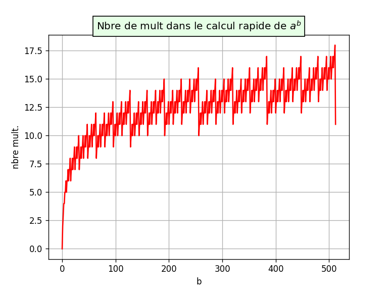

```python
MAX = 513
bs = [k for k in range(0, MAX)]
plt.plot(bs, [nbre_mult(b) for b in bs], color='r')
plt.xlabel('b')
plt.ylabel('nbre mult.')
plt.title('Nbre de mult dans le calcul rapide de $a^b$', bbox=dict(facecolor=(0.9, 1, 0.9)))
plt.grid()
plt.show()
```

### Étude théorique

Une analyse simple de l'algorithme montre qu'à chaque étape de l'itération il y a une ou deux multiplications selon que la valeur de la variable `k` est paire ou non. Le nombre total de multiplications est donc compris entre une ou deux fois le nombre d'étapes.

Une bonne façon d'analyser le problème consiste à considérer l'écriture binaire de l'exposant $b$.

**Exemple :** Si on prend $b=19 = 16 + 2 + 1 = 2^4 + 2^1 + 2^0$, alors $b$ s'écrit `10011` en binaire.

| `k` | parité de `k` | nbre mult. |
| --- | --- | --- |
| `10011` | impair | 2 |
| `1001` | impair | 2 |
| `100` | pair | 1 |
| `10` | pair | 1 |
| `1` | impair | 2 |

L'algorithme d'exponentiation rapide décrit ci-dessus se comporte comme si on parcourait les bits de l'exposant $b$ de droite à gauche : lorsqu'un bit vaut 1 (`k` impair) on a deux multiplications, et lorsqu'il vaut 0 une seule.

On peut résumer ceci en disant que

$$ c(b) = |b|_2 + \omega_2(b),$$

où $\omega_2(b)$ désigne le nombre de bits valant 1 dans l'écriture binaire de $b$.

L'expression obtenue ci-dessus pour $c(b)$ explique les nombreuses oscillations dans la courbe obtenue expérimentalement.

Mais en se souvenant que pour un entier $b$ strictement positif, on a $|b|_2=\lfloor\log_2{b}\rfloor + 1$ et $1\leq \omega_2(b) \leq |b|_2$, on peut déduire que $$ \lfloor\log_2{b}\rfloor + 2 \leq c(b) \leq 2\lfloor\log_2\rfloor + 2.$$

Cet encadrement montre que la «croissance» de $c(b)$ est logarithmique. C'est ce qui explique le succès de l'algorithme d'exponentiation rapide avec des nombres de quelques centaines de chiffres.

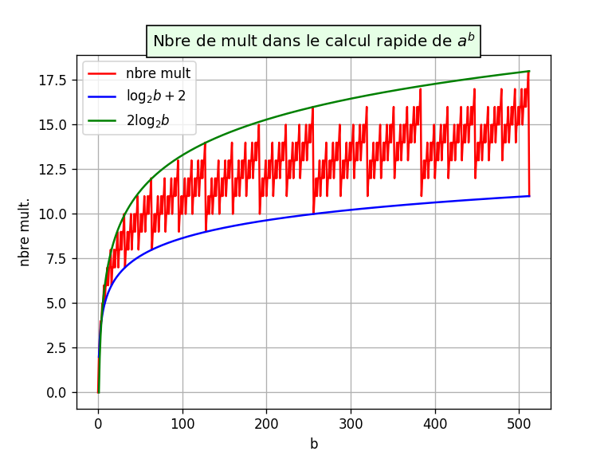

```python
from math import log
plt.plot(bs, [nbre_mult(b) for b in bs], color='r')
plt.plot(bs[1:], [log(b, 2)+2 for b in bs[1:]], color='b')
plt.plot(bs[1:], [2*log(b, 2) for b in bs[1:]], color='g')
plt.xlabel('b')
plt.ylabel('nbre mult.')
plt.title('Nbre de mult dans le calcul rapide de $a^b$', bbox=dict(facecolor=(0.9, 1, 0.9)))
plt.grid()
plt.legend(['nbre mult', '$\log_2{b}+2$', '$2\log_2{b}$'])
plt.show()
```